# ISL Ch10 Unsupervised Learning

Andrew Washburn

23 June, 2018

pg 373

Supervised learning deals with a response $Y$ and predictors $X$. *Unsupervised learning* only has the predictors, with no response variable. This is challenging because there is no way to check our work because there is no true answer.

## 10.2 Principal Component Analysis

page 374

Principal components in regression represent directions where the feature space is highly variable. They also define lines and subspaces that are as close as possible to the data cloud. In an unsupervised approach, principal components can be used to better understand datasets. Suppose we wish to visualize $\mathbf X_{n \times p}$. Examining two-dimensional scatterplots requires $\binom{p}{2} = p (p - 1) / 2$ plots; for example, $p = 10$ requires 45 plots! We would rather like to find a low-dimensional representation of the data that captures most of the information. *Principal components analysis* performs this by creating variables that are interesting. The first principal component is the normalized linear combination of the features

$$Z_1 = \phi_{11}X_1 + \phi_{21}X_2 + \cdots + \phi_{p1}X_p$$

that has the largest variance. Normalized means the loadings are constrained $||\phi_1||_2 = 1$, otherwise the variance could be arbitrarily large. We compute the first PC by centering each of the variables to have mean of zero. Then we solve the following optimization problem

$$\begin{eqnarray}
\text{subject to}& \qquad ||\phi_1||_2 = 1 \\
\max_{\phi_1}& \qquad \frac{1}{n} \sum_{i = 1}^n \mathbf X \phi_1
\end{eqnarray}$$

The objective could be written as $\frac{1}{n} \sum_{i = 1}^n z^2_{ij}$. Since the result $\frac{1}{n} \sum_{i = 1}^n x_{ij} = 0$ (scaled predictors), then $\mu_{z_1} = 0$ as well. Hence the objective that we are maximizing is just the sample variance of $z_1$, which is referred to as the scores of the first principal component. This loading vector $\phi_1$ represents the direction in feature space along which the data vary most. This problem can be solved by eigen decomposition, a standard technique in linear algebra (which is on my list, see Strang’s *Introduction to Linear Algebra*). The second principal component $\phi_2$ is the linear combination of $\mathbf X \phi_2$ that has maximal variance and is uncorrelated with $Z_1$. It turns out constraining $Z_2$ to be uncorrelated with $Z_1$ is equivilant to $\phi_1 \cdot \phi_2 = 0$, they are orthogonal. Once we have the computed principal components, we can plot them against each other to produce low-dimensional views of the data. Geometrically, this amounts to projecting the original data down onto the subspace spanned by $\over\phi$.

### Another Interpretation of Principal Components

We can view a three dimensional dataset projected onto two principal compoents whose loadings best represent a 2-D planes that minimizes the RSS (accounts for the most variance). In this interpretation, principal components create a low-dimensional linear surface that is *closest* to the observations. The first principal component loading vector has a very special property: it is the line in $p$-dimensional space that is closest to the observations (using average squared Euclidian distance). The appeal of this interpretation is clear: we seek a single dimension of data (a line) that lies as close as possible to all the data points. Thus $M$ principal components, subject to the orthogonal constraint, build up a linear hyper-plane of $M$-dimensions that is close the the observations. This can be written as

$$\mathbf X_{n \times p} \approx Z_{n \times m} \phi_{m \times p}$$

In other words, together the $M$ principal component score vectors and $M$ principal component loading vectors can give a good approximation to the data when $M$ is sufficiently large.

### Scaling the Variables

We already mentioned the observations must be centered, therefore, the results obtained from PCA will also depend on whether the variables have been individually scaled. For example: variables measuring `Murder`, `Rape`, and `Assualt`, are reported as number of occurences per 100,000 people, and `UrbanPop` is the percentage of urban population in a state, with variances 18.97, 87.73, 6945.16, and 209.5 respectively. Without scaling these variances, the principal components will skew the variance information based on context rather than content. If `Assault` were measured in occurences per 100 people, the unscaled variance will be scaled down by 1,000. In linear regression, multipling the coefficients by constants does not affect the model, but in PCA scaling does matter. Therefore, we typically scale the variables to have $\mu = 0$ and $\sigma = 1$ before performing PCA. Only in certain settings, where the variables are measured in the same units, should scaling not be performed.

### Uniqueness of the Principal Components

The principal component loading vector is unique in direction, not sign $\phi = -\phi$. Same is true with the score vectors $Z = -Z$. If the sign is flipped on both the loading vector and score vector, the signs will cancel and the final product of the two quantities is unchanged.

### Proportion of Variance Explained.

How much information is lost by projecting the observations onto the first few principal components? Or, more generally, what is the *proportion of variance explained* (PVE) by each principal component. The PVE of the $m$th principal component is

$$\text{PVE} = \frac{\text{Variance of }Z_m}{\text{Total Variance}} = \frac{||\mathbf X \phi_m||_2^2}{\text{var}(\mathbf X)}$$

### Deciding how many Principal Components to Use

In general $\mathbf X_{n \times p}$ has $\min (n - 1, p)$ distinct principal components. But we only want the *best* ones! But there is no hard criteria for *best*. We can use a *scree plot*, plotting the PVE and cumulative PVE and looking for the elbow of the plot. It is ad-hoc, and there isn’t a well defined cut-off (like for automation). Generally, we look at the first few principal components for trends, and if there are not any, more principal components will not improve the picture.

## 10.3 Clustering Methods

page 385

Clustering is a broad set of techniques for finding subgroups, or *clusters*, in a data set. Of course, what does it mean to be mathematically *similar* or *different*? Suppose $\mathbf X_{n \times p}$ describes tissue samples of patients with breast cancer, described by clinical measurements like tumor stage or grade. We may assume the samples are heterogeneous, with unknown subtypes of breast cancer burried in the data. Another application in marketing would be to find groups of people who like similar movies and then *recommend* movies they haven’t seen, but would probably like given the statistics of similar users. Clustering can find these subgroups.

- PCA looks to find a low-dimensional summary of the observations that explains a good fraction of the variance
- Clustering finds homogeneous subgroups amoung the observations.

### K-Means Clustering

pg 386

Partition data into $K$ distinct, non-overlapping clusters. First, specify the number of clusters $K$, then the $K$-means algorithm will assign each observation to exactly one of the $K$ clusters. The procedure results from a simple and intuitive mathematical problem. Let $C_1, \ldots, C_K$ denote sets containing observations in each cluster satisfying two properties:

1. $C_1 \cup \ldots \cup C_K = \{1, \ldots, n\}$ each observation belongs to at least one of the $K$ clusters
2. $C_k \cap C_{k'} = \emptyset$ for all $k \neq k'$ the clusters are non-overlapping: no observation belongs to more than one cluster.

Example: the $i$th observation is in the $k$th cluster, then $i \in C_k$. The within-cluster-variation should be as small as possible (homogeneous) defined as $W(C_k)$. How do we define this? The most common choice is the squared Eucidian distance

$$W(C_k) = \frac{1}{|C_k|} \sum_{i, i' \in C_k} \sum_{j = 1}^p (x_{ij} - x_{i'j})^2$$

This is the pairwise squared Euclidian distances between the observations in the $k$th cluster, weighted by the number of observations in the $k$th cluster. We forumlate an optimization problem to minimize this quantity summed amoung all clusters. This is a difficult problem to solve precisely, since there are almost $K^n$ ways to partition $n$ observations into $K$ clusters. But the following algorithm can find a pretty good local optimum. It is guaranteed to decrease the objective at each step.

- **Algorithm** *K-Means CLustering*
1. Initially assign a randoml number $1$ to $K$ to each of the observations.
2. Iterate until the cluster assignments stop changing:
   1. For each of the $K$ clusters, compute the *centroid*.
   2. Assign each observation to the closest cluster centroid (where closest is the Euclidian distance)

To understand why this works, we illustrate the following

$$W(C_k) = 2 \sum_{i, i' \in C_k} \sum_{j = 1}^p (x_{ij} - \bar x_{kj})^2$$

Where $\bar x_{kj} = \frac{1}{|C_k|} \sum_{i \in C_k} x_{ij}$ is the mean for feature $j$ in cluster $C_k$. In Step 2(a) the cluster means are the constants that minimize sum-of-squared deviations, and in Step 2(b), reallocating the observations can only improve the variance. The algorithm continues until nothing changes, in other words a local optimum has been reached. Since $K$-means finds a local rather than a global optimum, and uses a random intitialization, it is important to run the algorithm multiple times to obtain a robust result.

### Hierarchial Clustering

Hierarchial clustering helps us choose $K$ using a dendrogram and a bottom-up or agglomerative clustering approach. We start with a dendrogram of all observations, and then move up the tree. Leaves fuse into branches, branches into other branches, and eventually a stump. The higher up the tree, the more different the observations. More precisely: for any two observations, we can look for the point in the tree where branche containing these two observations first fuse. The fusion height measures how different the two observations are. Horizontal similarity has no meaning. A single dendrogram describes the entire series of clusters from $K = 1, \ldots, n$. The term *hierarchial* refers to the fact that clusters obtained by cutting the dendrogram at a given height are necessarily nested within the clusters obtained by cutting the dendrogram at any greater height.

The hierarchial clustering dendrogram algorithm is very simple. Define some sort of dissimilarity between each pair of observations (like Euclidian distance). For each iteration, the two observations that are most similar are fused with the branch node measured as the center between the observation pair. There are now $n - 1$ clusters. This continues until the stump.

**Algorithm** *Hierarchial Clustering*

1. Begin with $n$ observations and a measure (such as Euclidian distance) of all the $\binom{n}{2} = n(n - 1) / 2$ pariwise dissimilarities. Treat each observation as its own cluster.
2. For $i = n, n-1, \ldots, 2$:
   1. Examine all pairwise inter-cluster dissimilarities amongthe $i$ clusters and identify the cluster pairs that are least dissimilar (that is, most similar). Fuse these two clusters The dissimilarity between these two clusters indicates the height in the dendrogram at which the fusion should be placed.
   2. Compute the new pairwise inter-cluster dissimilarities amoung the $i-1$ remaining clusters. ***

One problem is that we have a dissimilarity between observations, but what about clusters and individual observations? We extend the dissimilarity idea using the *linkage*. The Average and Complete linkages are preferred because they yield the most balanced dendrograms. Centroid linkages can invert whereby two clusters are fused at a height below either of the individual clusters in the dendrogram.

[output not shown]

So far our dissimilarity measure has been the Eucidian distance. But other measures can be employed, like *correlation-based distance* that considers two observations similar if their features are highly correlated. For example, consider an online retailer interested in clustering shoppers based on their past shopping histories in order to identify subgroups of similar shoppers. Suppose the data takes the form of a matrix where rows are shoppers and columns are items available to purchase, and the values are the number of times the shopper has purchased the item. If Euclidian distance is used, shoppers who have bought nothing at all would be grouped together, not entirely desireable. On the other hand, correlation-based distance groups shoppers with similar preferences (similar shoppers, we all want our tribe), ignoring whether some shoppers are high volume customers or not. Scaling is another issue (like number of socks vs. number of computers).

### Some Practical Issues

Clustering involves decision making. Each one can have a huge impact on results, and a wide range of parameters should be considered.

- Should observations or features be standardized?
- For hierarchial clustering:
- What dissimilarity measure should be used.
- What type of linkage?
- Where to cut the dendrogram?
- For $K$-means clustering, how many clusters should be used?

Since clustering is an unsupervised technique, there is no way to qualify the output. Domain expertise needs to regulate whether the results make sense or not. Statistical techniques exist to quanitfy a valid cluster, but there is no overall consensus.

Clusters are also not very robust to outliers, and subsetting and resampling the dataset can lead to very different results!

And lastly, clustering should not be considered as the absolute truth. Rather, it should constitute a starting point for developing scientific hypothesis and further study, preferable on an independent data set.

## Ch10 Lab 1 Principal Components Analysis

page 401

```r
# USAarrests descibes crime rates and urban pop proportion for all 50 US states
# exploring the dataset
apply(USArrests, 2, mean)
```

```
##   Murder  Assault UrbanPop     Rape
##    7.788  170.760   65.540   21.232
```

```r
apply(USArrests, 2, var)
```

```
##     Murder    Assault   UrbanPop       Rape
##   18.97047 6945.16571  209.51878   87.72916
```

```r
# we need to scale the variables so mean = 0, var = 1

pr.out <- prcomp(USArrests, scale. = T)
pr.out$center # adjusted means
```

```
##   Murder  Assault UrbanPop     Rape
##    7.788  170.760   65.540   21.232
```

```r
pr.out$scale # scaled std
```

```
##    Murder   Assault  UrbanPop      Rape
##  4.355510 83.337661 14.474763  9.366385
```

```r
pr.out$rotation # PC loading vectors matrix
```

```
##                 PC1        PC2        PC3         PC4
## Murder   -0.5358995  0.4181809 -0.3412327  0.64922780
## Assault  -0.5831836  0.1879856 -0.2681484 -0.74340748
## UrbanPop -0.2781909 -0.8728062 -0.3780158  0.13387773
## Rape     -0.5434321 -0.1673186  0.8177779  0.08902432
```

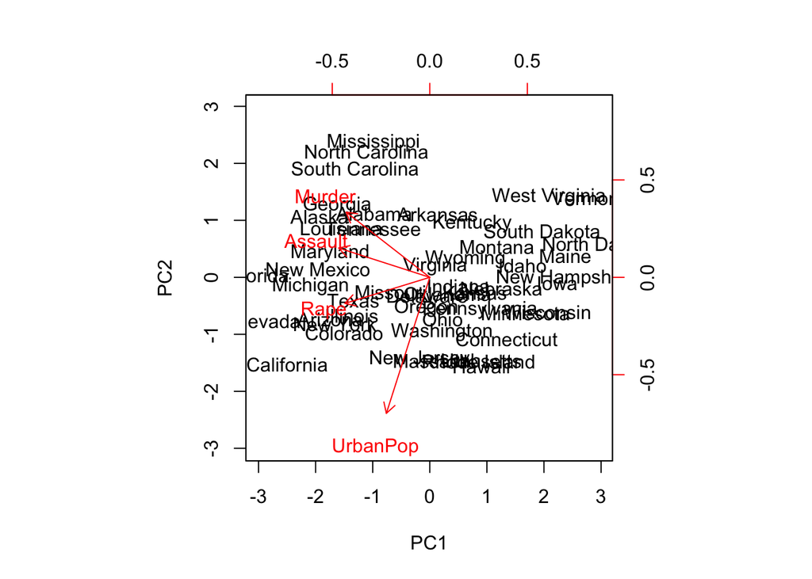

```r
# in general, there are min(n-1, p) principal components

biplot(pr.out, scale = 0) # scale=0 means the arrows represent the loadings
```

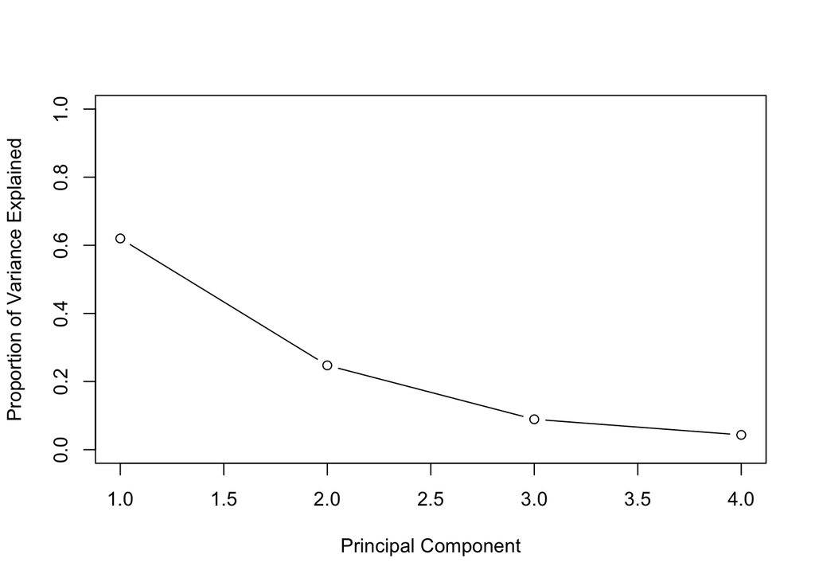

```r
# plot the PVE
pve <- pr.out$sdev^2 / sum(pr.out$sdev^2)
plot(pve,
     xlab = "Principal Component", ylab = "Proportion of Variance Explained",
     ylim = c(0,1), type = 'b')
```

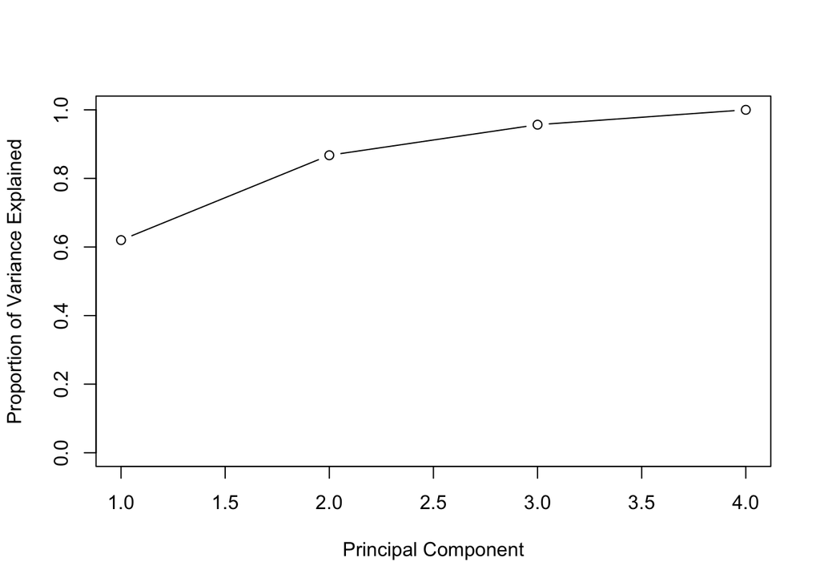

```r
plot(cumsum(pve),
     xlab = "Principal Component", ylab = "Proportion of Variance Explained",
     ylim = c(0,1), type = 'b')
```

```r
library(tidyverse)
```

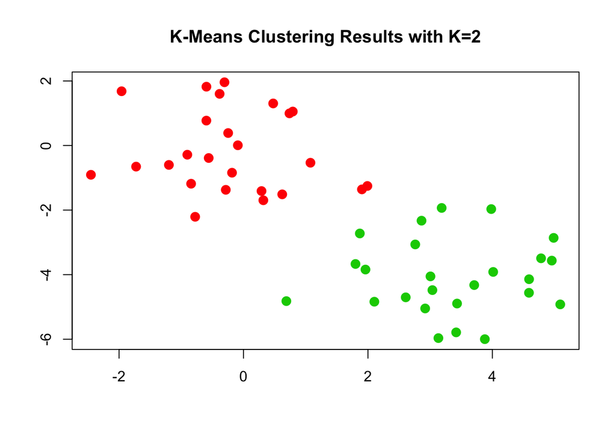

```r
# K-Means
set.seed(2)
x <- matrix(rnorm(50*2), ncol = 2)
x[1:25, 1] <- x[1:25, 1] + 3
x[1:25, 2] <- x[1:25, 2] - 4

# nstart means number of initial random iterations, keeps the best one. recommended > 20

km.out <- kmeans(x, 2, nstart = 20)
plot(x, col = (km.out$cluster + 1), pch = 20, cex = 2,
     main = "K-Means Clustering Results with K=2", xlab = "", ylab = "")
```

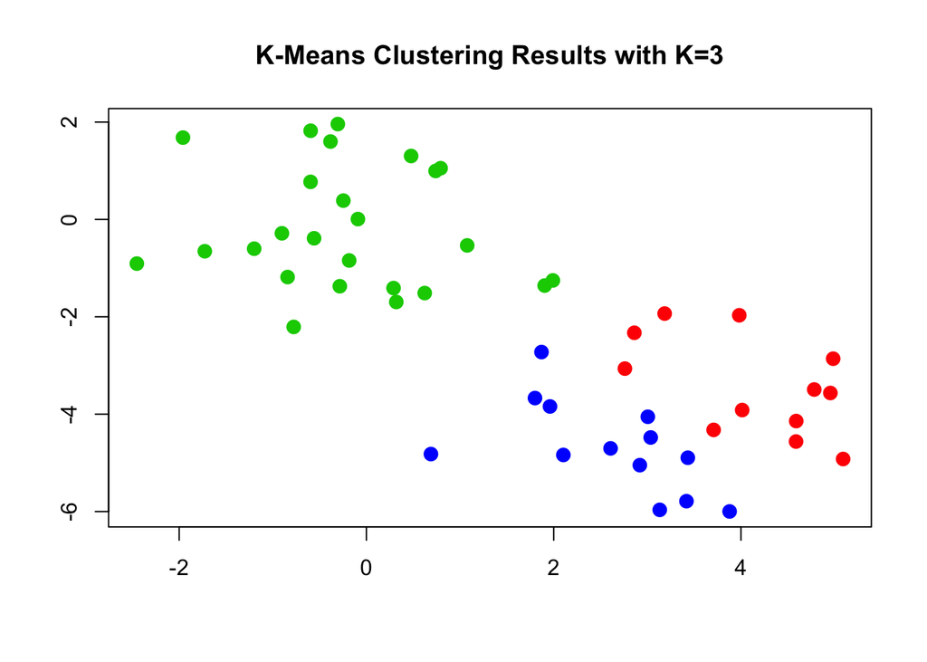

```r
set.seed(3)
km.out <- kmeans(x, 3, nstart = 1)
plot(x, col = (km.out$cluster + 1), pch = 20, cex = 2,
     main = "K-Means Clustering Results with K=3", xlab = "", ylab = "")
```

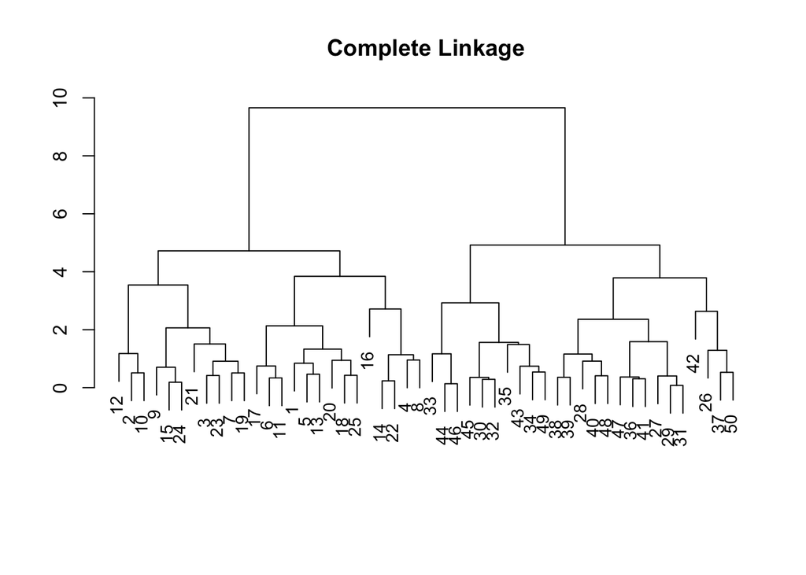

```r
# Hierarchial Clustering
hc.complete <- hclust(dist(x), method = "complete")
hc.average <- hclust(dist(x), method = "average")
hc.single <- hclust(dist(x), method = "single")

plot(hc.complete, main = "Complete Linkage", xlab = "", ylab = "", sub = "", cex = .9)
```

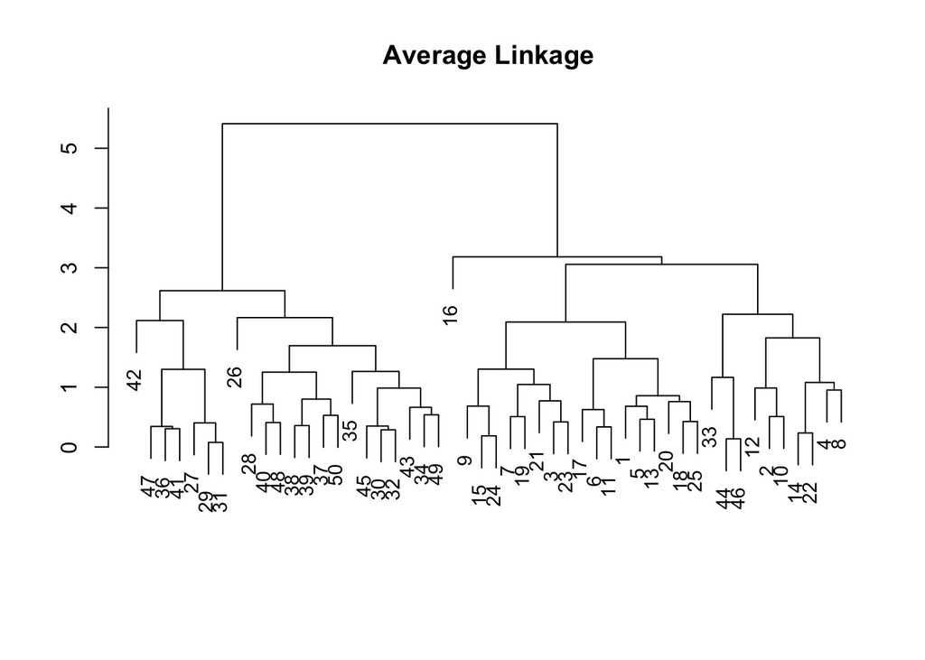

```r
plot(hc.average, main = "Average Linkage", xlab = "", ylab = "", sub = "", cex = .9)
```

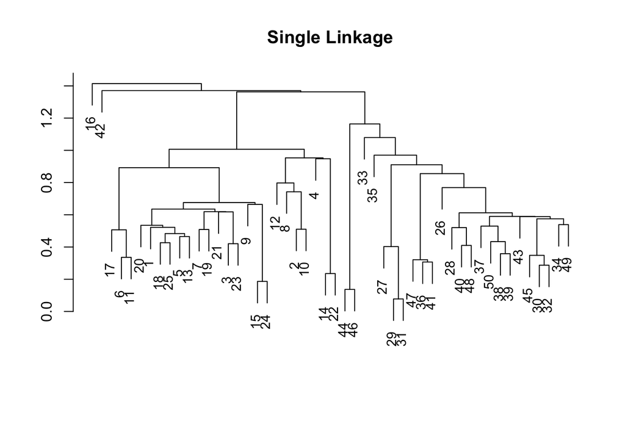

```r
plot(hc.single, main = "Single Linkage", xlab = "", ylab = "", sub = "", cex = .9)
```

```r
# the cutree() returns labels for a given number of clusters
```

```r
library(ISLR)
nci.labs <- NCI60$labs
nci.data <- NCI60$data
table(nci.labs)
```

```
## nci.labs
##      BREAST         CNS       COLON K562A-repro K562B-repro    LEUKEMIA
##           7           5           7           1           1           6
## MCF7A-repro MCF7D-repro    MELANOMA       NSCLC     OVARIAN    PROSTATE
##           1           1           8           9           6           2
##       RENAL     UNKNOWN
##           9           1
```

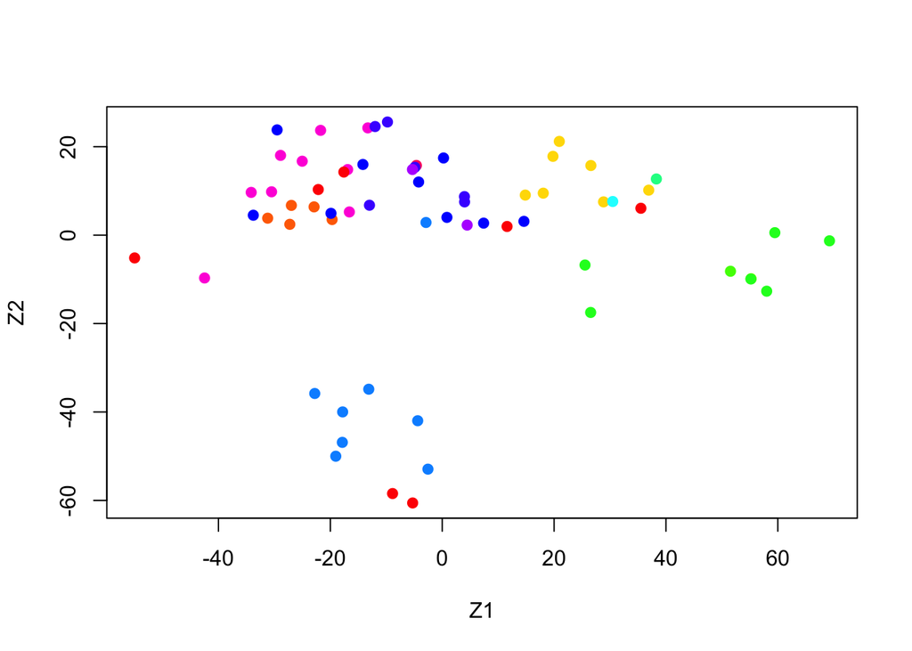

```r
pr.out <- prcomp(nci.data, scale. = T)

Cols <- function(vec) {
  cols <- rainbow(length(unique(vec)))
  return(cols[as.numeric(as.factor(vec))])
}

plot(pr.out$x[,1:2], col = Cols(nci.labs), pch = 19, xlab = "Z1", ylab = "Z2")
```

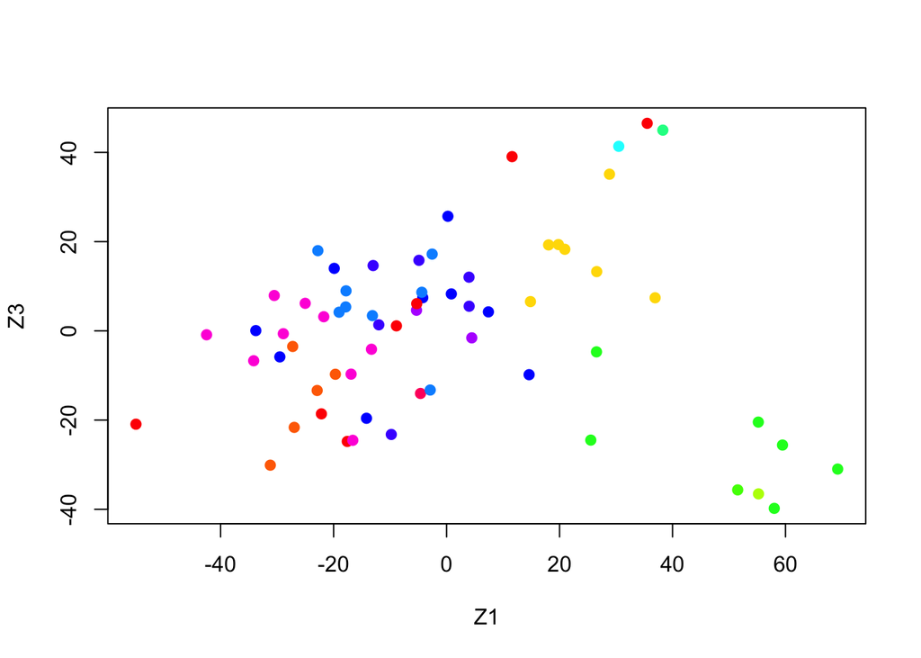

```r
plot(pr.out$x[,c(1,3)], col = Cols(nci.labs), pch = 19, xlab = "Z1", ylab = "Z3")
```

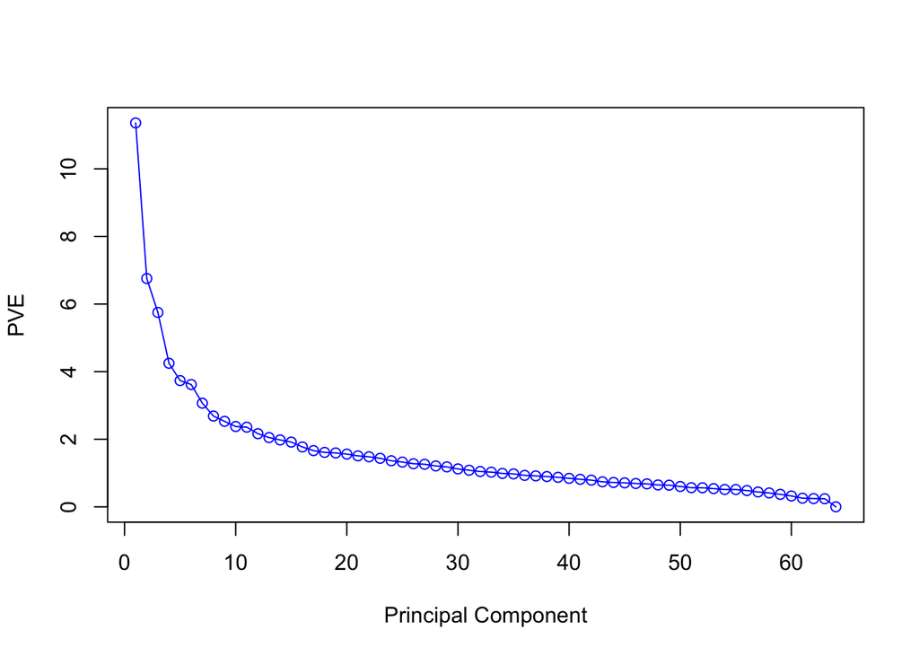

```r
pve <- 100 * pr.out$sdev^2 / sum(pr.out$sdev^2)
plot(pve, type = 'o', ylab = "PVE", xlab = "Principal Component", col = "blue")
```

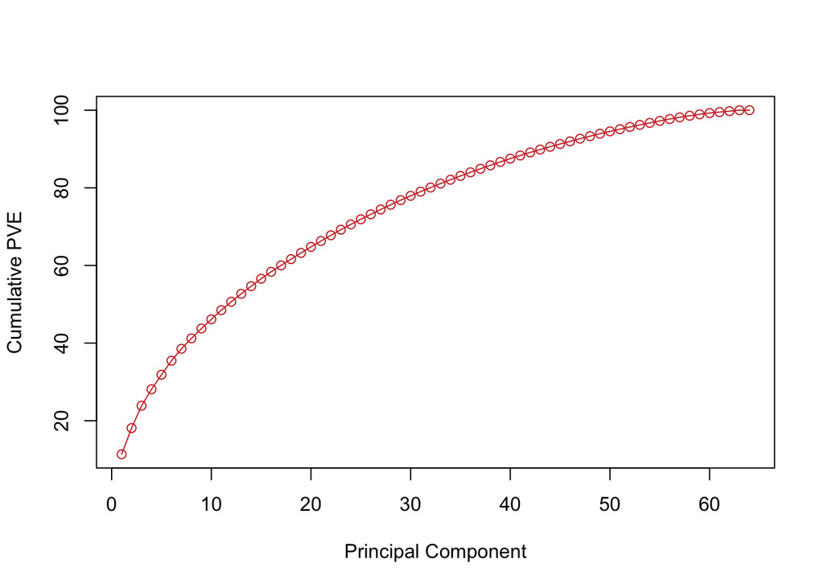

```r
plot(cumsum(pve), type = 'o', ylab = "Cumulative PVE", xlab = "Principal Component", col = "brown3")
```

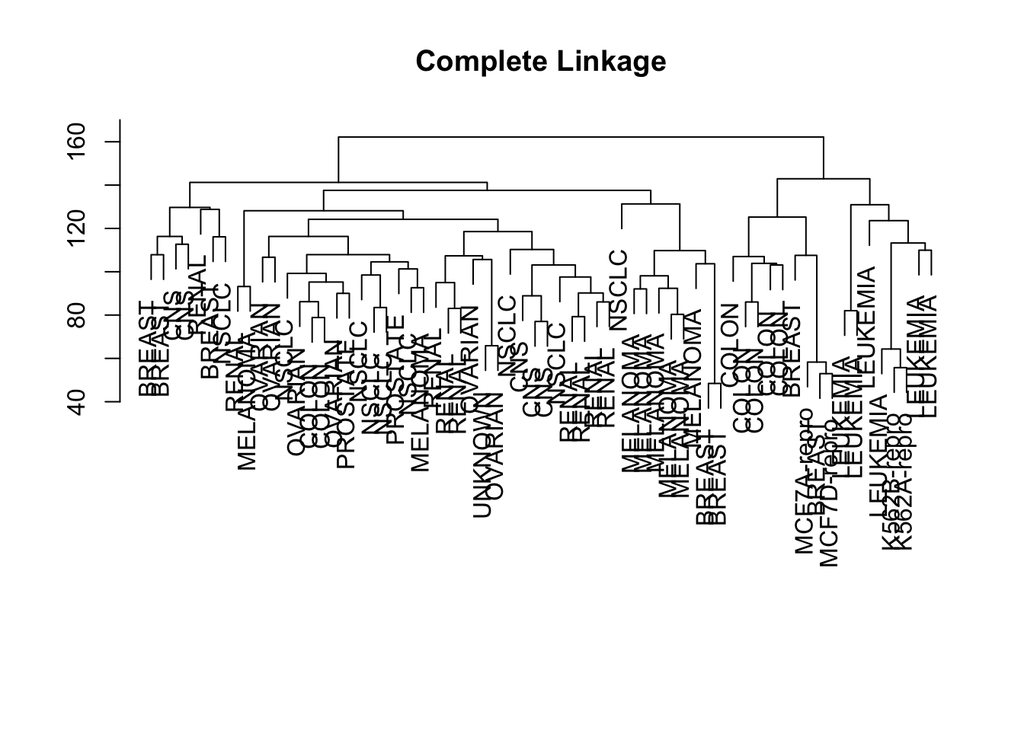

```r
# first seven principal components account 40% variance. See the elbow

sd.data <- scale(nci.data)
data.dist <- dist(sd.data)
plot(hclust(data.dist), labels = nci.labs,
     main = "Complete Linkage", xlab = "", ylab = "", sub = "")
```

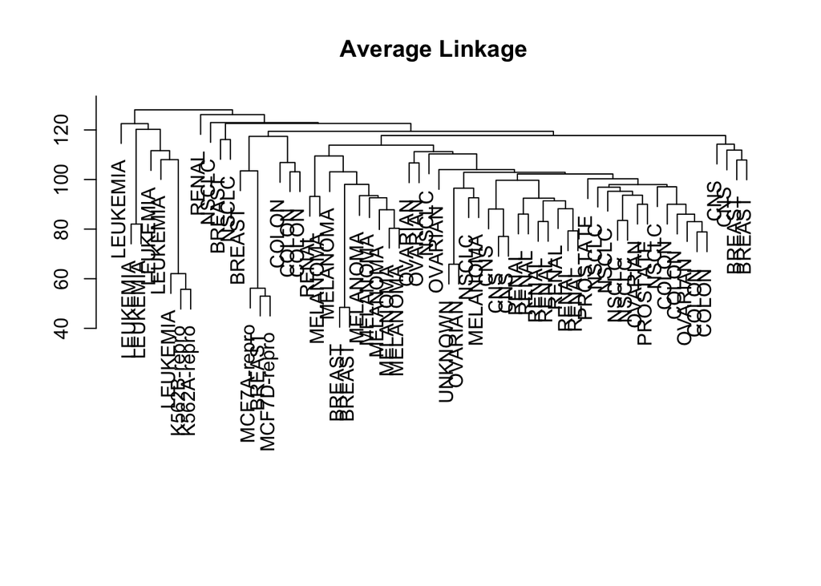

```r
plot(hclust(data.dist, method = "average"), labels = nci.labs,
     main = "Average Linkage", xlab = "", ylab = "", sub = "")
```

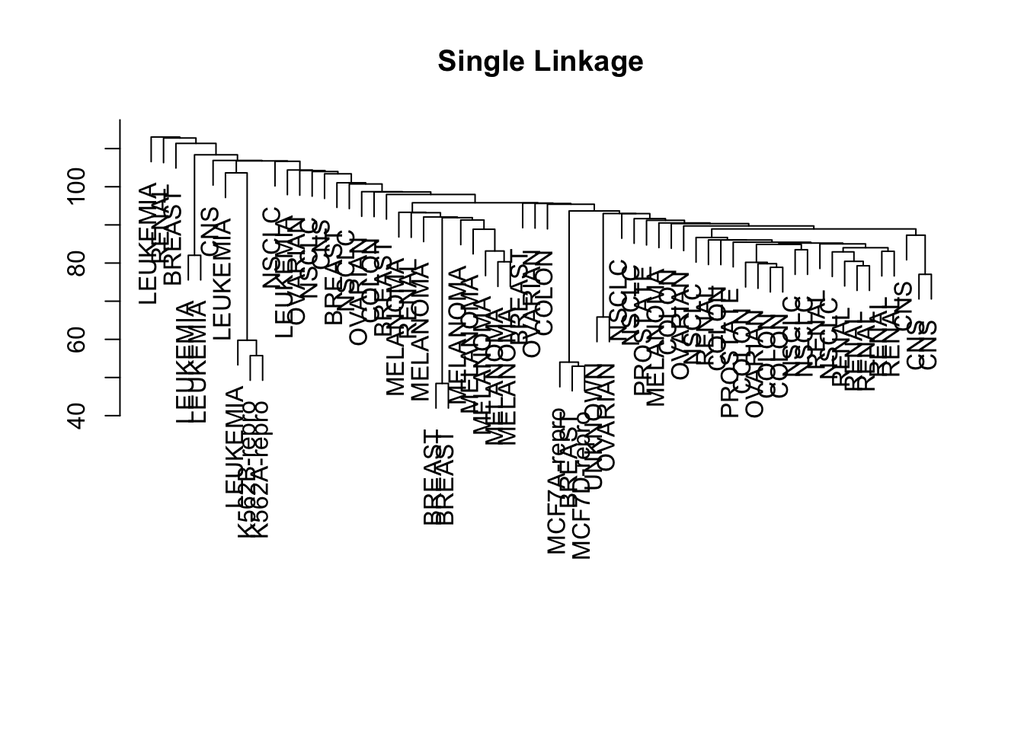

```r
plot(hclust(data.dist, method = "single"), labels = nci.labs,
     main = "Single Linkage", xlab = "", ylab = "", sub = "")
```

```r
hc.out <- hclust(dist(sd.data))
hc.clusters <- cutree(hc.out, 4)
table(hc.clusters, nci.labs)
```

```
##            nci.labs
## hc.clusters BREAST CNS COLON K562A-repro K562B-repro LEUKEMIA MCF7A-repro
##           1      2   3     2           0           0        0           0
##           2      3   2     0           0           0        0           0
##           3      0   0     0           1           1        6           0
##           4      2   0     5           0           0        0           1
##            nci.labs
## hc.clusters MCF7D-repro MELANOMA NSCLC OVARIAN PROSTATE RENAL UNKNOWN
##           1           0        8     8       6        2     8       1
##           2           0        0     1       0        0     1       0
##           3           0        0     0       0        0     0       0
##           4           1        0     0       0        0     0       0
```

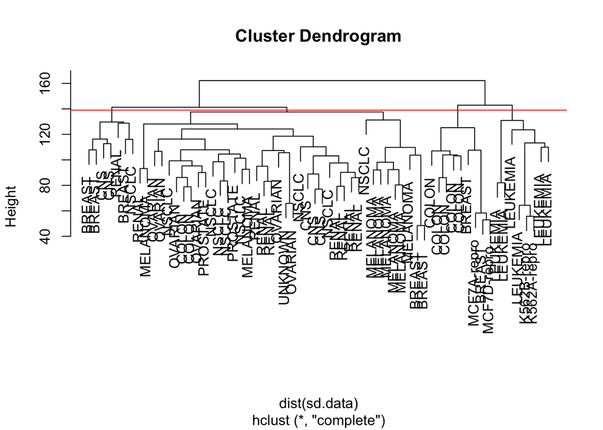

```r
plot(hc.out, labels = nci.labs); abline(h = 139, col = "red")
```

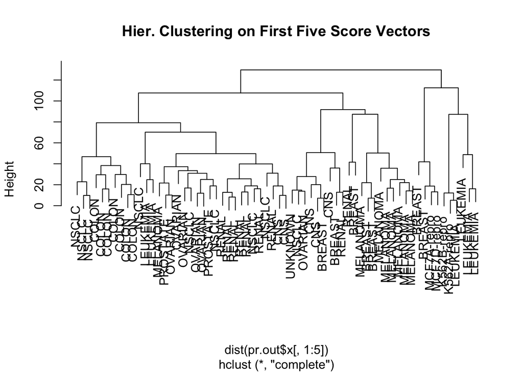

```r
hc.out <- hclust(dist(pr.out$x[,1:5]))
plot(hc.out, labels = nci.labs, main = "Hier. Clustering on First Five Score Vectors")
```

```r
table(cutree(hc.out, 4), nci.labs)
```

```
##    nci.labs
##     BREAST CNS COLON K562A-repro K562B-repro LEUKEMIA MCF7A-repro
##   1      0   2     7           0           0        2           0
##   2      5   3     0           0           0        0           0
##   3      0   0     0           1           1        4           0
##   4      2   0     0           0           0        0           1
##    nci.labs
##     MCF7D-repro MELANOMA NSCLC OVARIAN PROSTATE RENAL UNKNOWN
##   1           0        1     8       5        2     7       0
##   2           0        7     1       1        0     2       1
##   3           0        0     0       0        0     0       0
##   4           1        0     0       0        0     0       0
```